# Warnings, Errors, and Getting Help

# Reading

- Bryan (2020)
- “R Faq - How to Make a Great R Reproducible Example” (n.d.)
- Wickham (2019)

# Dependencies

```r
install.packages('lubridate', 'assertthat', 'reprex')
```

# Messages, warnings, and errors

- *Message*: Things are fine, but here’s some information you should know
- *Warning*: Uhhhh I’m gonna keep going, but maybe this isn’t what you want
- *Error*: Nope. I’m stopping here. You need to fix the thing.

```r
message('Hey, just FYI')
```

```
## Hey, just FYI
```

```r
warning('Uhhhh might want to check this out')
stop('Noooooo')
```

```
## Error in eval(expr, envir, enclos): Noooooo
```

# Where to go for help

- [Rubber duck debugging](https://en.wikipedia.org/wiki/Rubber_duck_debugging)
- Isolate the problem
- Restart your session: Session $\to$ Restart R
- Local help: `?fun`
- StackOverflow: https://stackoverflow.com/questions/tagged/r
- CRAN $\to$ BugReports (usually GitHub Issues)

# Example: Dates are often problems

```r
library(lubridate)
add_six_months = function(date_str) {
    parsed_dates = parse_date_time(date_str, orders = 'mdY')
    parsed_dates %m+% months(6)
}

some_data = c('June 2002', 'May 15, 2007', 'August 2007')
add_six_months(some_data)
```

```
## Warning: 2 failed to parse.
```

```
## [1] NA               "2007-11-15 UTC" NA
```

- Note that this is a warning, not an error
  - R won’t stop running here (unless we tell it to)
  - Errors might not show up until much later in our code, making it hard to identify the root cause
  - Or they might cause invisible problems, eg, by default `lm()` silently drops observations with missing values

# To catch warnings

- Set `options(warn = 2)` to turn all warnings into errors
- Use `tryCatch()` with the `warning` argument
  - Example: https://stackoverflow.com/questions/8217901/breaking-loop-when-warnings-appear-in-r/8218794#8218794
- Write a unit test
- My preferred approach: Add an **assertion** to your primary code

```r
## Using an assertion to prevent warnings from cascading
library(assertthat)

six_months_later = add_six_months(some_data)
```

```
## Warning: 2 failed to parse.
```

```r
assert_that(all(!is.na(six_months_later)),
            msg = 'Missing values in `six_months_later`')
```

```
## Error: Missing values in `six_months_later`
```

# Debugging

- Let’s start by using the RStudio debugger to **isolate the problem**

```r
debugonce(add_six_months)
add_six_months(some_data)
```

```
## debugging in: add_six_months(some_data)
## debug at <text>#3: {
##     parsed_dates = parse_date_time(date_str, orders = "mdY")
##     parsed_dates %m+% months(6)
## }
## debug at <text>#4: parsed_dates = parse_date_time(date_str, orders = "mdY")
```

```
## debug at <text>#5: parsed_dates %m+% months(6)
## exiting from: add_six_months(some_data)
```

```
## [1] NA               "2007-11-15 UTC" NA
```

- The problem is in `lubridate::parse_date_time()`.
- *Spend a few minutes reading the documentation for this function and playing around with the call.*
  - What does the argument `orders` do?

```r
?parse_date_time
```

```r
parse_date_time(some_data, orders = 'mdY')
```

```
## [1] NA               "2007-05-15 UTC" NA
```

- Let’s try SO: https://stackoverflow.com/search?q=%5BR%5D+lubridate+month-year

```r
parse_date_time(some_data, orders = c('mY', 'mdY'))
```

```
## [1] "2002-06-01 UTC" "2007-05-15 UTC" "2007-08-01 UTC"
```

- *Make this change in `add_six_months()` and confirm it no longer trips the assertion.*

# Another example: More fun with dates

```r
more_data = c('May 7, 2017', 'May 19, 2017', 'May Fifth, 2017')
mdy(more_data)
```

```
## [1] "2017-05-07" "2017-05-19" "2017-05-20"
```

- SO doesn’t seem so helpful: https://stackoverflow.com/search?q=%5BR%5D+lubridate+written+days
- The CRAN page for `lubridate` includes a link to report bugs: https://cran.r-project.org/web/packages/lubridate/index.html

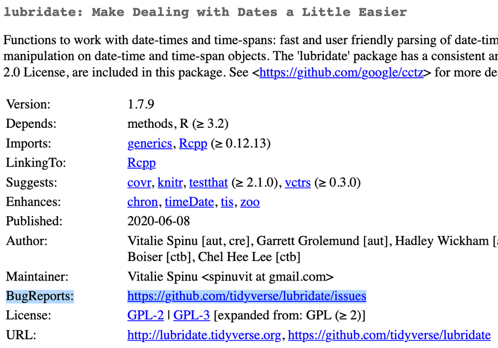

Screenshot of `lubridate` on CRAN, highlighting the BugReports field

- Trying a couple of searches gives us a promising result: https://github.com/tidyverse/lubridate/issues?q=is%3Aissue+is%3Aopen+mdy

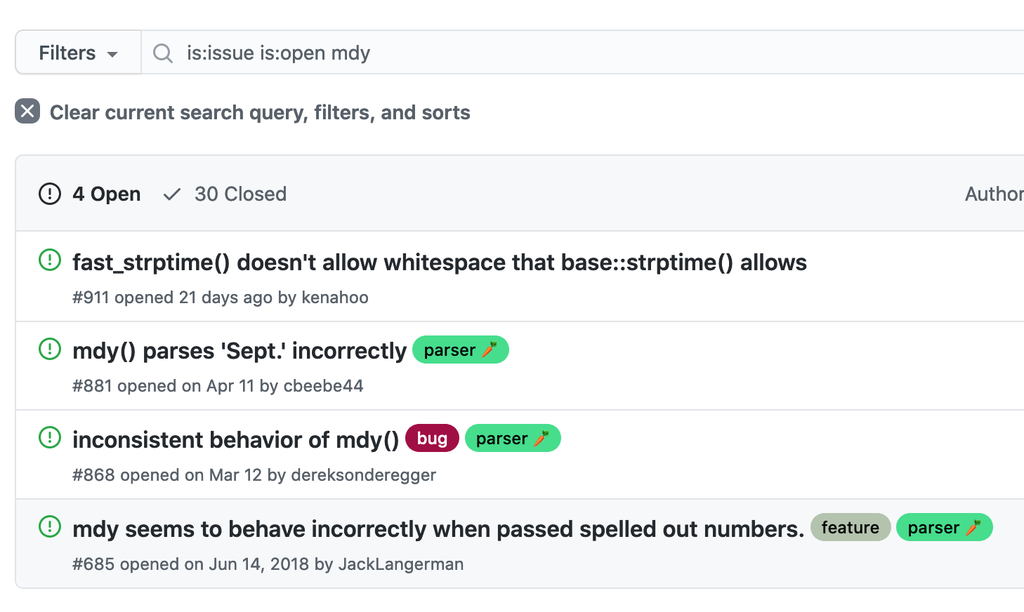

This is a known bug; it looks like they’re thinking about doing something about it, but the only workaround is to create an NA: https://github.com/tidyverse/lubridate/issues/685

# Writing a reproducible example: `reprex`

- https://reprex.tidyverse.org/
- https://reprex.tidyverse.org/articles/articles/learn-reprex.html
- https://reprex.tidyverse.org/articles/reprex-dos-and-donts.html
- *Practice by writing a reprex for one of our two examples*

# Do not do these things in your reprex (or anywhere else)

[Or Jenny Bryan will come to your office and set your computer on fire](https://www.tidyverse.org/blog/2017/12/workflow-vs-script/).

- `setwd('/users/danhicks/projects/catsaregreat/myscript/')`
  - Used to ensure that R is running where your file is
  - Unnecessary if you’re opening different projects in different RStudio sessions
  - Will cause irrelevant errors on any other system
  - Instead, use `file.path()` or `here::here()` to build paths
- `rm(list=ls())`
  - Used because people think it clears out the global environment
  - Unnecessary if you’re regularly using Session $\to$ Restart R
  - Also unnecessary at the top of a `Rmd` file, which is always knit in a new session
  - Doesn’t actually clear out the global environment
    - eg, doesn’t unload packages or reset `options()`

Not on Bryan’s list, but also don’t do it:

- `require(package)`
  - If `package` is installed, will act just like `library()`
  - If not, will return `FALSE`
    - The script will keep going until there’s an error about a missing function 300 lines later
    - Probably not the error you wanted help with
    - Annoying to debug because I have no idea where the function is supposed to come from
  - If `library()` can’t find the package, it immediately raises an error
    - I can tell right away what package needs to be installed

# Debugging in RStudio

[This week’s lab](https://github.com/data-science-methods/lab-w03-debugging) introduces you to some of RStudio’s debugging tools.

Bryan, Jenny. 2020. “Object of Type ‘Closure’ Is Not Subsettable.” Presented at the RSTUDIO::CONF 2020, January 31. https://rstudio.com/resources/rstudioconf-2020/object-of-type-closure-is-not-subsettable/.

“R Faq - How to Make a Great R Reproducible Example.” n.d. Stack Overflow. Accessed August 31, 2018. https://stackoverflow.com/questions/5963269/how-to-make-a-great-r-reproducible-example.

Wickham, Hadley. 2019. “Debugging.” In *Advanced R, Second Edition*, ch. 22. CRC Press. https://adv-r.hadley.nz/debugging.html.